# Agrupación de Datos - Final Project - Obesidad

#### **💥 Definir los rangos de hiperparámetros para KMeans**

```python
# Parámetros para KMeans con distribución de valores
kmeans_param_dist = {
    'n_clusters': np.arange(2, 11),  # Número de clústeres a utilizar, variando de 2 a 10
    'init': ['k-means++', 'random'],  # Método de inicialización de los centroides: 'k-means++' (mejor distribución) o 'random' (aleatorio)
    'max_iter': [100, 300, 500],  # Número máximo de iteraciones para cada ejecución del algoritmo
    'n_init': np.arange(10, 101, 10)  # Número de veces que el algoritmo se ejecuta con diferentes inicializaciones de centroides
}

# Creación del modelo KMeans
kmeans_random = KMeans(random_state=42)

# Configuración de RandomSearch para KMeans
random_search_kmeans_random = RandomizedSearchCV(estimator=kmeans_random, param_distributions=kmeans_param_dist, n_iter=100, cv=5, n_jobs=-1, verbose=2, random_state=42)
random_search_kmeans_random.fit(_X_train)

# Mejor combinación de parámetros encontrada para KMeans
best_kmeans_model_random = random_search_kmeans_random.best_estimator_
print(f'Mejores parámetros para KMeans: {random_search_kmeans_random.best_params_}')
```

```
Fitting 5 folds for each of 100 candidates, totalling 500 fits
Mejores parámetros para KMeans: {'n_init': np.int64(30), 'n_clusters': np.int64(10), 'max_iter': 100, 'init': 'k-means++'}
```

#### **✳️ Predicción de Clusters**

```python
# Definir los parámetros para KMeans según lo indicado
kmeans2 = KMeans(
    n_init=np.int64(30),           # Número de veces que se ejecuta el algoritmo con diferentes centroides iniciales
    n_clusters=np.int64(10),       # Número de clústeres que deseas generar
    max_iter=100,        # Número máximo de iteraciones que se realizan por cada ejecución
    init='k-means++',       # Inicialización de los centroides, 'random' significa que se seleccionan aleatoriamente
    random_state=42      # Para asegurar reproducibilidad de los resultados
)

# Ajustar el modelo KMeans a las probabilidades de las clases (y_probs)
cluster_labels2 = kmeans2.fit_predict(X_scaled)  # Predicción de clústeres
optimized_df = df
optimized_df['Cluster'] = cluster_labels2

kmeans_metrics(kmeans2, cluster_labels2, X_scaled)
```

```
Inercia: 3927.8352798132173
Índice de Silueta: 0.2356330890289011
Coeficiente de Calinski-Harabasz: 393.87466024781764
Índice de Davies-Bouldin: 1.3068588785883022
```

#### **🔍 Analisis de modelos Random Forest basado en metricas (Sin Ajuste de Hiperparámetros v.s GridSearchCV v.s. RandomizedSearchCV)**

| **Modelo** | **Precisión** | **F1-Score** | **Recall** | **Interpretación** |
| --- | --- | --- | --- | --- |
| **Random Forest Sin Ajuste de Hiperparámetros** | **0.66** | **0.6477** | **0.6572** | Este modelo tiene un desempeño general moderado. Presenta una precisión aceptable, pero podría mejorar en recall y F1-Score, especialmente para algunas clases con menor soporte. |
| **Random Forest Ajustado con GridSearchCV** | **0.68** | **0.6749** | **0.6809** | El modelo ajustado con GridSearchCV muestra un rendimiento superior en comparación con el modelo sin ajuste. La mejora en el F1-Score y recall sugiere que el ajuste de hiperparámetros fue efectivo. |
| **Random Forest Ajustado con RandomizedSearchCV** | **0.64** | **0.6256** | **0.6430** | A pesar del ajuste con RandomizedSearchCV, este modelo tiene el peor desempeño de los tres. Las métricas más bajas indican que este ajuste no mejora suficientemente el rendimiento. |

Tras analizar los resultados, el modelo **Random Forest Ajustado con GridSearchCV** parece ser el más óptimo entre los tres. Aunque la diferencia en las métricas es pequeña, este modelo presenta una ligera mejora tanto en **F1-Score** como en **Recall** en comparación con los otros modelos:

- **Random Forest Sin Ajuste de Hiperparámetros:** F1-Score = `0.6477`, Recall = `0.6572`.
- **Random Forest Ajustado con GridSearchCV:** F1-Score = `0.6749`, Recall = `0.6809`.
- **Random Forest Ajustado con RandomizedSearchCV:** F1-Score = `0.6256`, Recall = `0.6430`.

Aunque la diferencia en F1-Score y Recall no es tan grande, el modelo ajustado con **GridSearchCV** logra un balance ligeramente mejor entre precisión, recall y F1-Score ponderado, lo que sugiere que el ajuste de hiperparámetros realizado por GridSearchCV optimiza el modelo de manera más efectiva que los otros enfoques. Por lo tanto, el **Random Forest Ajustado con GridSearchCV** sería la opción más adecuada para lograr un rendimiento óptimo.

#### **🔍 Analisis de modelos Kmeans basado en metricas (Sin Ajuste de Hiperparámetros v.s GridSearchCV v.s. RandomizedSearchCV)**

[output not shown]

### Conclusión:

- **K-Means sin ajuste** muestra el peor desempeño en términos de cohesión y separación, con la inercia más alta y un índice de silueta bajo, lo que indica una mayor dispersión y menor calidad en la separación de los clústeres.
- **K-Means con ajuste de GridSearch** mejora ligeramente la separación de los clústeres y reduce la inercia, aunque presenta una leve disminución en la cohesión, evidenciada por la caída en el coeficiente de Calinski-Harabasz.
- **K-Means con ajuste de RandomSearch** ofrece la mejor separación de clústeres, con el índice de silueta más alto y la inercia más baja. Sin embargo, esta mejora en la separación ocurre a costa de una ligera pérdida de cohesión, reflejada en el coeficiente de Calinski-Harabasz más bajo.

En resumen, **K-Means con ajuste de RandomSearch** parece ser el modelo más equilibrado en términos de separación, aunque con una ligera penalización en cohesión.

### **⚛️ Visualización**

#### **⭕️ Visualización de Resultados de Clústeres**

#### 📊 Agrupamiento K-Means (Sin Ajuste de Hiperparámetros)

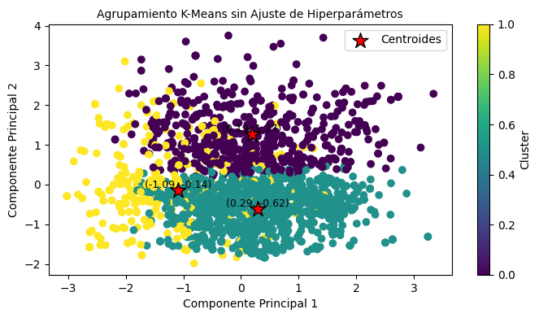

```python
import matplotlib.pyplot as plt
from sklearn.decomposition import PCA

# Reducir la dimensionalidad de los datos a 2D usando PCA
pca = PCA(n_components=2)  # Cambiar a 2 componentes para visualizar en 2D
X_pca = pca.fit_transform(X_scaled)  # Transformación PCA de los datos
C_pca = pca.transform(kmeans.cluster_centers_)  # Transformación PCA de los centroides

# Visualizar los clústeres en 2D con coordenadas de los centroides
plt.figure(figsize=(8, 4))  # Establecer el tamaño de la figura
plt.scatter(X_pca[:, 0], X_pca[:, 1], c=labels_kmeans, cmap='viridis', marker='o')  # Graficar los puntos con colores según el clúster
plt.scatter(C_pca[:, 0], C_pca[:, 1], marker='*', s=200, c='red', label='Centroides', edgecolor='black')  # Graficar los centroides

# Añadir coordenadas de cada centroide
for i, (x, y) in enumerate(C_pca):
    plt.text(x, y, f'({x:.2f}, {y:.2f})', fontsize=9, ha='center', va='bottom', color='black')

# Etiquetas y título
plt.xlabel("Componente Principal 1")  # Etiqueta del eje X
plt.ylabel("Componente Principal 2")  # Etiqueta del eje Y
plt.title("Agrupamiento K-Means sin Ajuste de Hiperparámetros", fontsize=10)  # Título del gráfico
plt.colorbar(label='Cluster')  # Barra de colores para los clústeres
plt.legend()  # Leyenda para los centroides
plt.show()  # Mostrar el gráfico
```

#### 📊 Agrupamiento K-Means (con ajuste de Hiperparámetros GridSearchCV)

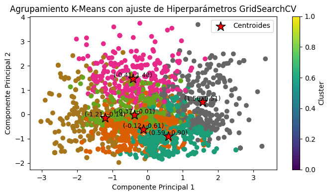

```python
# Reducir la dimensionalidad de los datos a 2D usando PCA (para visualización)
pca = PCA(n_components=2)  # Cambiar a 2D para el gráfico
X_pca = pca.fit_transform(X_scaled)  # Transformación PCA
C_pca = pca.transform(kmeans1.cluster_centers_)  # Transformar los centroides a 2D

# Visualizar los clústeres en 2D
plt.figure(figsize=(8, 4))  # Establecer el tamaño de la figura
plt.scatter(X_pca[:, 0], X_pca[:, 1], c=cluster_labels1, cmap='Dark2', marker='o')  # Puntos de datos
plt.scatter(C_pca[:, 0], C_pca[:, 1], marker='*', s=200, c='red', label='Centroides', edgecolor='black')  # Centroides

# Añadir coordenadas de cada centroide
for i, (x, y) in enumerate(C_pca):
    plt.text(x, y, f'({x:.2f}, {y:.2f})', fontsize=9, ha='center', va='bottom', color='black')

plt.xlabel("Componente Principal 1")  # Etiqueta del eje X
plt.ylabel("Componente Principal 2")  # Etiqueta del eje Y
plt.title("Agrupamiento K-Means con ajuste de Hiperparámetros GridSearchCV")  # Título del gráfico
plt.colorbar(label='Cluster')  # Barra de colores para los clústeres
plt.legend()  # Leyenda para los centroides
plt.show()
```